# ANOVA

v1.0.0

Author

Allan Omondi

Published

21 June 2026

```r
# `installed.packages()` retrieves a matrix of all installed packages
# `[, "Package"]` extracts on the "Package" column from the matrix of all
# packages. This contains the name of the package.
# The %in% operator is used to test if the specified package is in the matrix of
# all packages
# `dependencies = TRUE` instructs R to install not only the specified package but
# also its dependencies

if (!"pacman" %in% installed.packages()[, "Package"]) {
  install.packages("pacman", dependencies = TRUE)
  library("pacman")
}

# For reading data from a CSV file
pacman::p_load("readr")
# For data visualization
pacman::p_load("ggplot2")
# For data visualization of missing data
pacman::p_load("naniar")
# "Companion to Applied Regression" for diagnostic EDA using
pacman::p_load("car")
# For the Durbin-Watson Test (test of independence of errors [autocorrelation])
pacman::p_load("lmtest")
# For performing a test of normality for MANOVA
pacman::p_load("mvnormtest")
# For visualizing hypothesis tests in multivariate linear models
pacman::p_load("heplots")
```

# 1 Generate the Synthetic Dataset

## 1.1 4 Algorithms, 10 independent datasets, and 5 independent runs

This simulates data collected from a Machine Learning model comparison experiment. The research question in this simulation is:

> Is there a statistically significant difference in mean classification accuracy across the Machine Learning algorithms?

There are 4 algorithms, 10 independent datasets, and 5 independent runs per algorithm–dataset pair.

Execute the following R script to generate the synthetic dataset: `./data/synthetic-data-for-ml-model-comparison.R`

“**4 × 10 × 5 = 200 observations**” means:

- 4 algorithms
- 10 **independent datasets**
- 5 independent runs per algorithm–dataset pair

A “run” means:

- Different random seed
- Different initialization
- Possibly different train/test split

Therefore, the unit of analysis is the dataset, not the run. The 5 runs are replicates, not new experimental units.

## 1.2 NOT the same as Cross-Validation with Repeats

A run set up as a 10-Fold cross-validation with 5 repeats means:

For each algorithm on one dataset:

- The dataset is split into 10 folds
- The algorithm is trained and tested 10 times
- The entire 10-fold process is repeated 5 times

That gives 50 performance estimates per algorithm per dataset. However — and this is the critical part — those 50 values are **NOT independent observations**.

They are correlated because:

- The same data points appear in multiple folds
- Training sets overlap heavily
- Test sets are reused across repeats

This disqualifies it from being used in statistical tests of comparison that expect independence of observations.

## 1.3 Valid ways to Create Independent Datasets

1. Naturally distinct datasets
   - Different real-world sources
   - Different domains or tasks
   - Examples: Different UCI datasets, different companies’ sales datasets, different medical studies
2. Independent data-generating processes
   - Simulated datasets with independent random draws
   - Different parameterizations (noise level, class imbalance, feature correlations)
3. Independent experimental units
   - Different time periods where stationarity holds
   - Different geographical regions
   - Different populations

# 2 Load the Dataset

```r
ml_performance_data <- read_csv(
  "data/ml_results.csv",
  col_types = cols(
    Dataset   = col_factor(
      levels = c("Dataset_1", "Dataset_2", "Dataset_3",
                 "Dataset_4", "Dataset_5", "Dataset_6",
                 "Dataset_7", "Dataset_8", "Dataset_9",
                 "Dataset_10")),
    Run       = col_factor(levels = c("1", "2", "3", "4", "5")),
    Algorithm = col_factor(levels = c("Logistic Regression",
                                      "Random Forest",
                                      "SVM", "Gradient Boosting")),
    Accuracy  = col_double(),
    Precision = col_double(),
    Recall    = col_double()
    )
  )

head(ml_performance_data)
```

| Dataset | Run | Algorithm | Accuracy | Precision | Recall |
| --- | --- | --- | --- | --- | --- |
| Dataset_1 | 1 | Logistic Regression | 0.7031857 | 0.7471619 | 0.7017146 |
| Dataset_2 | 1 | Logistic Regression | 0.7130947 | 0.7393429 | 0.6897216 |
| Dataset_3 | 1 | Logistic Regression | 0.7667612 | 0.7614583 | 0.7540663 |
| Dataset_4 | 1 | Logistic Regression | 0.7221153 | 0.7329791 | 0.7215384 |
| Dataset_5 | 1 | Logistic Regression | 0.7238786 | 0.7155918 | 0.7372926 |
| Dataset_6 | 1 | Logistic Regression | 0.7714519 | 0.7619270 | 0.7384410 |

# 3 Initial EDA

**View the Dimensions**

The number of observations and variables.

```r
dim(ml_performance_data)
```

```
#> [1] 200   6
```

**View the Data Types**

```r
sapply(ml_performance_data, class)
```

```
#>   Dataset       Run Algorithm  Accuracy Precision    Recall
#>  "factor"  "factor"  "factor" "numeric" "numeric" "numeric"
```

```r
str(ml_performance_data)
```

```
#> spc_tbl_ [200 × 6] (S3: spec_tbl_df/tbl_df/tbl/data.frame)
#>  $ Dataset  : Factor w/ 10 levels "Dataset_1","Dataset_2",..: 1 2 3 4 5 6 7 8 9 10 ...
#>  $ Run      : Factor w/ 5 levels "1","2","3","4",..: 1 1 1 1 1 1 1 1 1 1 ...
#>  $ Algorithm: Factor w/ 4 levels "Logistic Regression",..: 1 1 1 1 1 1 1 1 1 1 ...
#>  $ Accuracy : num [1:200] 0.703 0.713 0.767 0.722 0.724 ...
#>  $ Precision: num [1:200] 0.747 0.739 0.761 0.733 0.716 ...
#>  $ Recall   : num [1:200] 0.702 0.69 0.754 0.722 0.737 ...
#>  - attr(*, "spec")=
#>   .. cols(
#>   ..   Dataset = col_factor(levels = c("Dataset_1", "Dataset_2", "Dataset_3", "Dataset_4", "Dataset_5",
#>   ..     "Dataset_6", "Dataset_7", "Dataset_8", "Dataset_9", "Dataset_10"
#>   ..     ), ordered = FALSE, include_na = FALSE),
#>   ..   Run = col_factor(levels = c("1", "2", "3", "4", "5"), ordered = FALSE, include_na = FALSE),
#>   ..   Algorithm = col_factor(levels = c("Logistic Regression", "Random Forest", "SVM", "Gradient Boosting"
#>   ..     ), ordered = FALSE, include_na = FALSE),
#>   ..   Accuracy = col_double(),
#>   ..   Precision = col_double(),
#>   ..   Recall = col_double()
#>   .. )
#>  - attr(*, "problems")=<externalptr>
```

**Descriptive Statistics**

Understanding your data can lead to:

- **Data cleaning:** To remove extreme outliers or impute missing data.
- **Data transformation:** To reduce skewness
- **Hypothesis formulation:** Formulate a hypothesis based on the patterns you identify
- **Choosing the appropriate statistical test:** You may notice properties of the data such as distributions or data types that suggest the use of parametric or non-parametric statistical tests and algorithms

Descriptive statistics can be used to understand your data. Typical descriptive statistics include:

1. **Measures of frequency:** count and percent
2. **Measures of central tendency:** mean, median, and mode
3. **Measures of distribution/dispersion/spread/scatter/variability:** minimum, quartiles, maximum, variance, standard deviation, coefficient of variation, range, interquartile range (IQR) [includes a box and whisker plot for visualization], kurtosis, skewness [includes a histogram for visualization]).
4. **Measures of relationship:** covariance and correlation [includes a correlation plot and a scatter plot for visualization].

## 3.1 **Measures of Frequency**

```r
ml_performance_data_freq <- ml_performance_data$Algorithm
cbind(frequency = table(ml_performance_data_freq),
      percentage = prop.table(table(ml_performance_data_freq)) * 100)
```

```
#>                     frequency percentage
#> Logistic Regression        50         25
#> Random Forest              50         25
#> SVM                        50         25
#> Gradient Boosting          50         25
```

## 3.2 **Measures of Central Tendency**

The median and the mean of each numeric variable:

```r
summary(ml_performance_data)
```

```
#>       Dataset   Run                  Algorithm     Accuracy
#>  Dataset_1:20   1:40   Logistic Regression:50   Min.   :0.6610
#>  Dataset_2:20   2:40   Random Forest      :50   1st Qu.:0.7308
#>  Dataset_3:20   3:40   SVM                :50   Median :0.7686
#>  Dataset_4:20   4:40   Gradient Boosting  :50   Mean   :0.7647
#>  Dataset_5:20   5:40                            3rd Qu.:0.7978
#>  Dataset_6:20                                   Max.   :0.9000
#>  (Other)  :80
#>    Precision          Recall
#>  Min.   :0.6465   Min.   :0.6585
#>  1st Qu.:0.7310   1st Qu.:0.7272
#>  Median :0.7633   Median :0.7661
#>  Mean   :0.7654   Mean   :0.7652
#>  3rd Qu.:0.7991   3rd Qu.:0.8029
#>  Max.   :0.9000   Max.   :0.9000
#>
```

The first 5 observations (rows) in the dataset:

```r
head(ml_performance_data, 5)
```

| Dataset | Run | Algorithm | Accuracy | Precision | Recall |
| --- | --- | --- | --- | --- | --- |
| Dataset_1 | 1 | Logistic Regression | 0.7031857 | 0.7471619 | 0.7017146 |
| Dataset_2 | 1 | Logistic Regression | 0.7130947 | 0.7393429 | 0.6897216 |
| Dataset_3 | 1 | Logistic Regression | 0.7667612 | 0.7614583 | 0.7540663 |
| Dataset_4 | 1 | Logistic Regression | 0.7221153 | 0.7329791 | 0.7215384 |
| Dataset_5 | 1 | Logistic Regression | 0.7238786 | 0.7155918 | 0.7372926 |

The last 5 observations (rows) in the dataset:

```r
tail(ml_performance_data, 5)
```

| Dataset | Run | Algorithm | Accuracy | Precision | Recall |
| --- | --- | --- | --- | --- | --- |
| Dataset_6 | 5 | Gradient Boosting | 0.8699164 | 0.8999944 | 0.8467981 |
| Dataset_7 | 5 | Gradient Boosting | 0.8280213 | 0.8125384 | 0.8254783 |
| Dataset_8 | 5 | Gradient Boosting | 0.7724619 | 0.7893765 | 0.7336315 |
| Dataset_9 | 5 | Gradient Boosting | 0.7916650 | 0.7664514 | 0.8152886 |
| Dataset_10 | 5 | Gradient Boosting | 0.7744356 | 0.7673447 | 0.8116338 |

## 3.3 **Measures of Distribution**

Measuring the variability in the dataset is important because the amount of variability determines **how well you can generalize** results from the sample to a new observation in the population.

Low variability is ideal because it means that you can better predict information about the population based on the sample data. High variability means that the values are less consistent, thus making it harder to make predictions.

The syntax `dataset[rows, columns]` can be used to specify the exact rows and columns to be considered. `dataset[, columns]` implies all rows will be considered. For example, specifying `BostonHousing[, -4]` implies all the columns except column number 4. This can also be stated as `BostonHousing[, c(1,2,3,5,6,7,8,9,10,11,12,13,14)]`. This allows us to perform calculations on only columns that are numeric, thus leaving out the columns termed as “factors” (categorical) or those that have a string data type.

### 3.3.1 **Variance**

```r
# `sapply()` is designed to apply a function to a variable in a dataset.
# In this case, we use `sapply()` to apply the `var()` function used to
# compute the variance.
sapply(ml_performance_data[,c(4)], var)
```

```
#>    Accuracy
#> 0.002014664
```

### 3.3.2 **Standard Deviation**

```r
sapply(ml_performance_data[,c(4)], sd)
```

```
#>   Accuracy
#> 0.04488501
```

### 3.3.3 **Kurtosis (Pearson)**

In “type = 2” (used in SPSS and SAS):

High kurtosis (leptokurtic) affects models that are sensitive to outliers. Estimates of the variance are also inflated. Low kurtosis (platykurtic) implies a possible underestimation of real-world variability. The typical remedy includes trimming outliers or using robust statistical methods that are less affected by outliers.

```r
pacman::p_load("e1071")
sapply(ml_performance_data[,c(4)],  kurtosis, type = 2)
```

```
#>   Accuracy
#> -0.4869903
```

### 3.3.4 **Skewness**

The skewness is used to identify the asymmetry of the distribution of results. Similar to kurtosis, there are several ways of computing the skewness.

Using “type = 2” (common in other statistical software like SPSS and SAS) can be interpreted as:

1. Skewness between -0.4 and 0.4 (inclusive) implies that there is no skew in the distribution of results; the distribution of results is symmetrical; it is a normal distribution; a Gaussian distribution.
2. Skewness above 0.4 implies a positive skew; a right-skewed distribution.
3. Skewness below -0.4 implies a negative skew; a left-skewed distribution.

Skewed data results in misleading averages and potentially biased model coefficients. The typical remedy to skewed data involves applying data transformations such as logarithmic, square-root, or Box–Cox, etc. to reduce skewness.

```r
sapply(ml_performance_data[,c(4)], skewness, type = 2)
```

```
#>   Accuracy
#> 0.09007845
```

As a data analyst, you need to confirm if the distortion in kurtosis or skewness is a data problem or it is a real-world insight. For example, a real-world insight could be that few customers drive most of the value. This is as opposed to always looking it at it as a distortion that needs to be corrected.

## 3.4 **Basic Visualizations**

### 3.4.1 **Histogram**

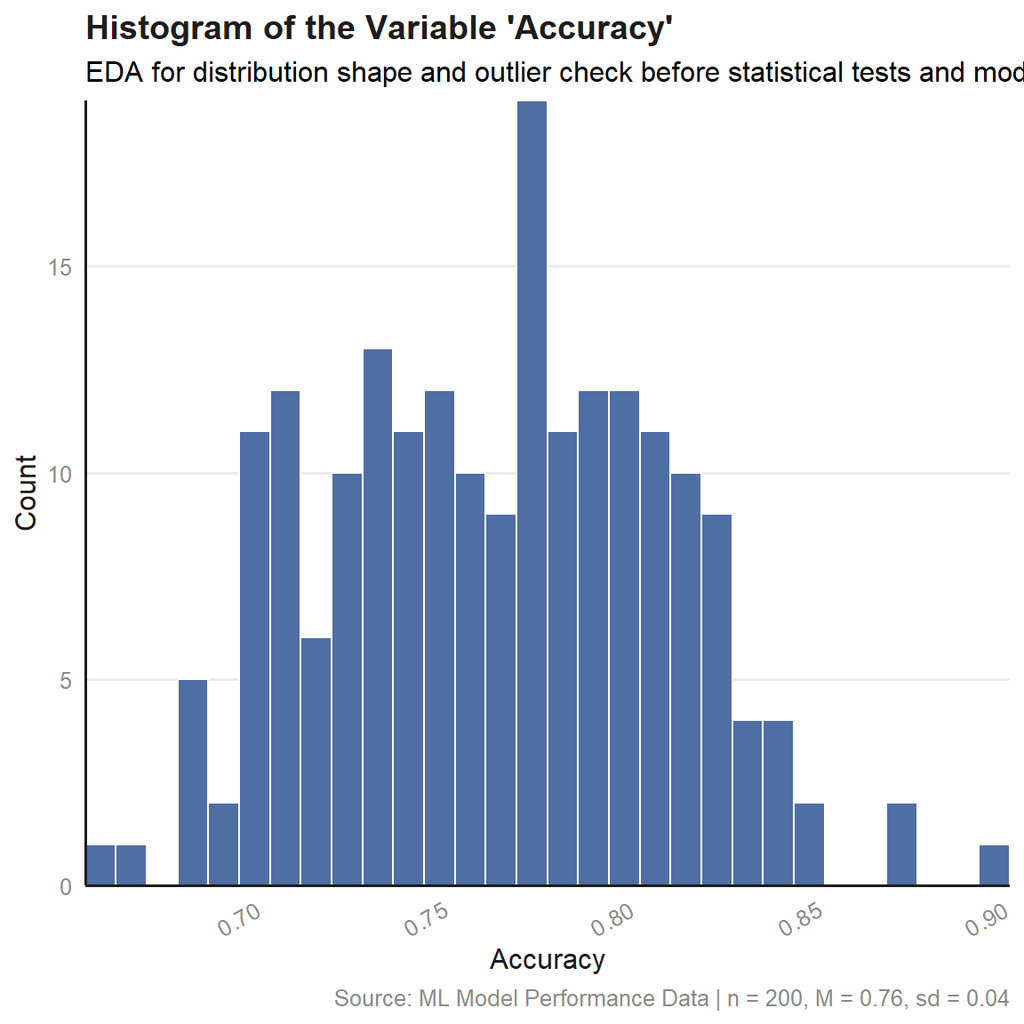

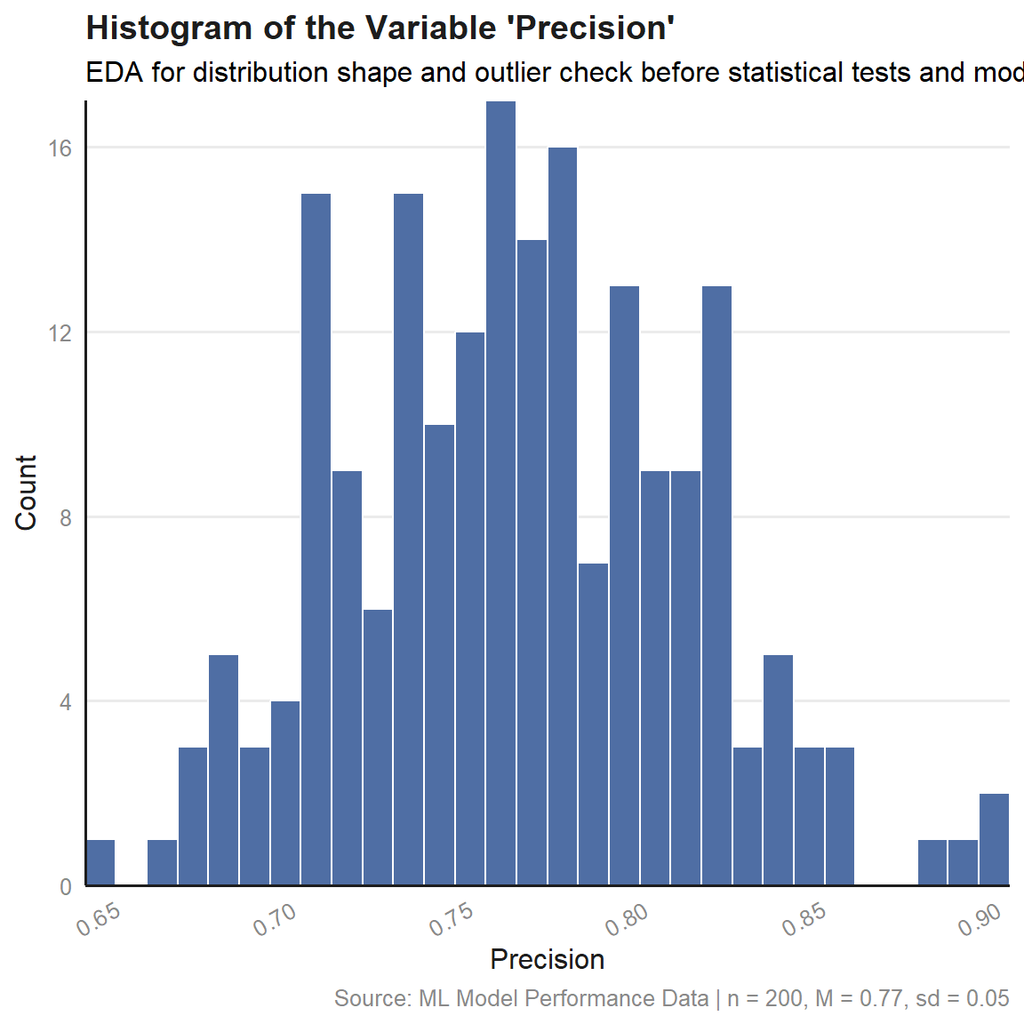

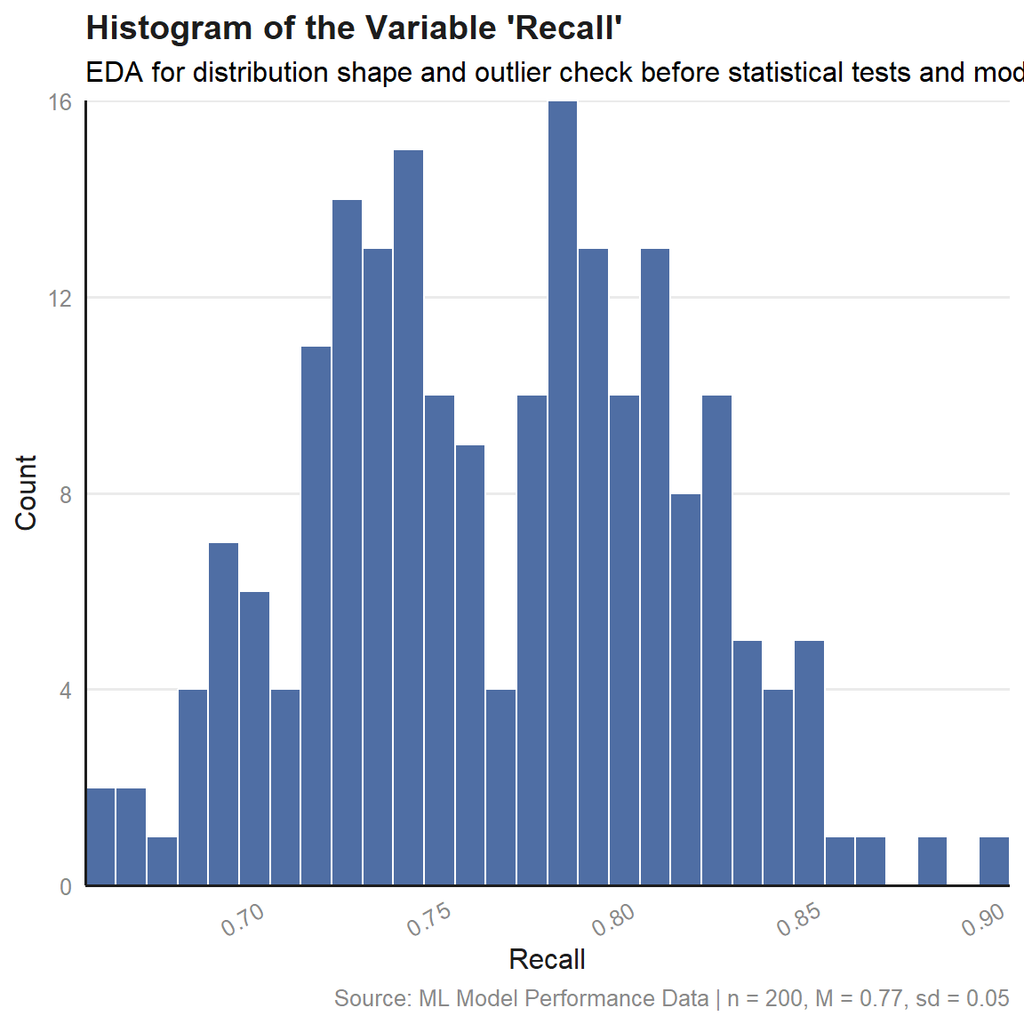

```r
# `col_index` identifies which column(s) (by position) are being plotted;
# seq_along() generates 1, 2, ..., ncol(data_frame) automatically,
# so every column in the data frame is covered without manually listing
# positions
col_index <- seq_along(ml_performance_data)
# the right-hand `col_index` (the full vector) is evaluated once when the
# loop starts; col_index is then reassigned to one position per iteration.
for (col_index in col_index) {

  # skip silently, with no message/warning, if the position does not exist
  # in the data (out of range) or if the column at that position is not
  # numeric; `next` moves straight to the following value of col_index
  if (col_index > ncol(ml_performance_data) ||
      !is.numeric(ml_performance_data[[col_index]])) {
    next
  }

  col_name <- names(ml_performance_data)[col_index]

  # for a histogram, the continuous variable goes on x; geom_histogram()
  # bins it and computes the count on y automatically, so y is left
  # unmapped here (the reverse of the boxplot version, where x was a
  # blank placeholder and y held the continuous variable)
  p <- ggplot2::ggplot(ml_performance_data, aes(x = .data[[col_name]])) +
    geom_histogram(bins = 30, fill = "#4F6EA4", color = "#FFFFFF") +

    # reduces the default 5% padding on the x and y axes
    scale_x_continuous(expand = expansion(mult = c(0.00, 0.00))) +
    scale_y_continuous(expand = expansion(mult = c(0.00, 0.00))) +
    labs(
      title = paste0("Histogram of the Variable '", col_name, "'"),
      subtitle = paste0("EDA for distribution shape and outlier check ",
                        "before statistical tests and modelling"),
      x = col_name,
      y = "Count",
      caption = paste0("Source: ML Model Performance Data | n = ",
                       nrow(ml_performance_data), ", ",
                       "M = ",
                       sprintf("%.2f",
                               mean(ml_performance_data[[col_name]], na.rm = TRUE)),
                       ", ",
                       "sd = ",
                       sprintf("%.2f",
                               sd(ml_performance_data[[col_name]], na.rm = TRUE)))
    ) +
    theme_minimal(base_size = 12) +

    theme(
      plot.title          = element_text(face = "bold", color = "#1D1D1D"),
      axis.title          = element_text(color = "#1D1D1D"),
      axis.text           = element_text(color = "#898989"),
      axis.text.x         = element_text(angle = 30, hjust = 1),
      plot.caption         = element_text(color = "#898989"),
      # removes vertical gridlines
      panel.grid.major.x  = element_blank(),
      panel.grid.minor.x  = element_blank(),
      # horizontal gridlines are kept (at major breaks only) since they
      # help the reader judge bar heights against the y-axis scale
      panel.grid.minor.y  = element_blank(),
      # draws only the x-axis and y-axis lines (the "L" frame)
      axis.line.x         = element_line(color = "#1D1D1D"),
      axis.line.y         = element_line(color = "#1D1D1D")
      # panel.border = element_rect(color = "#1D1D1D", fill = NA,
      #                            linewidth = 0.5)
    )
  # ggplot objects do not auto-print inside a for-loop, therefore,
  # each one must be printed explicitly otherwise it will never appear
  print(p)
}
```

### 3.4.2 **Box and Whisker Plot**

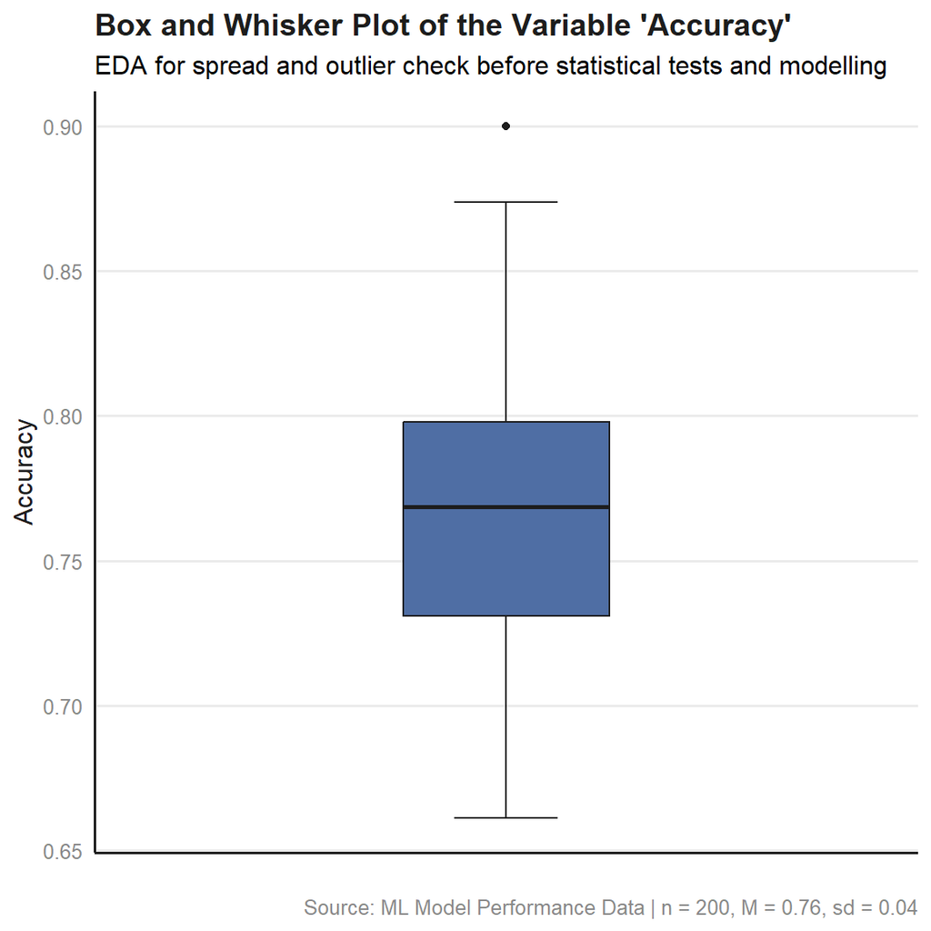

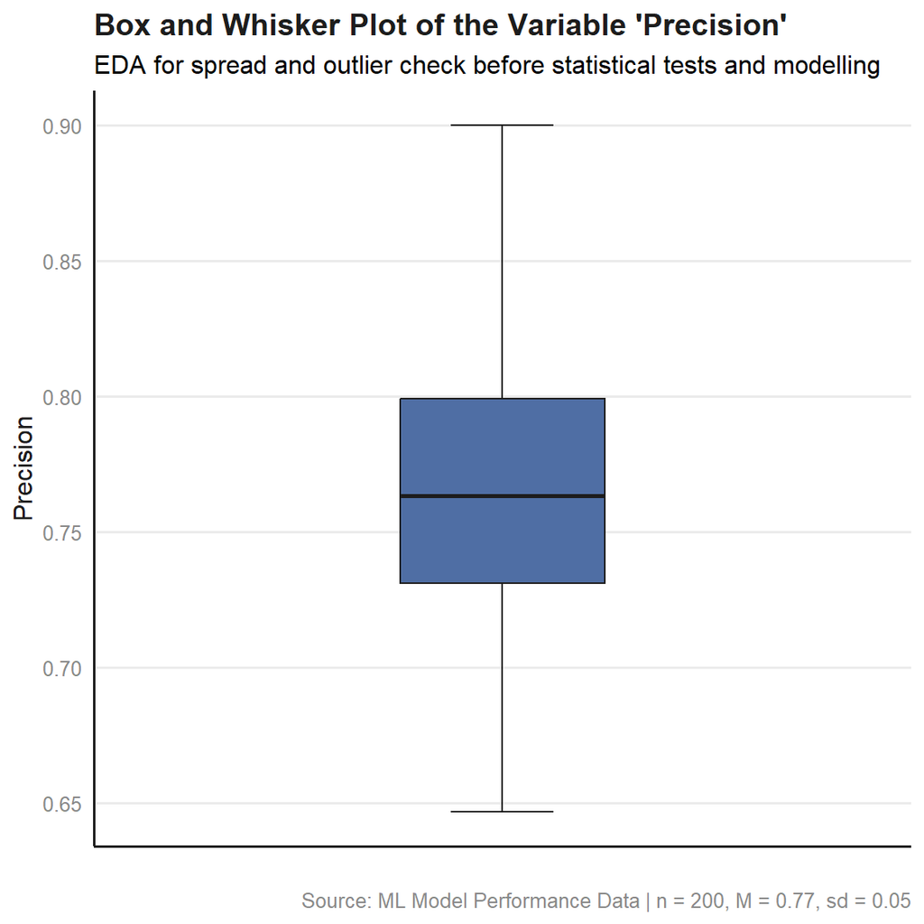

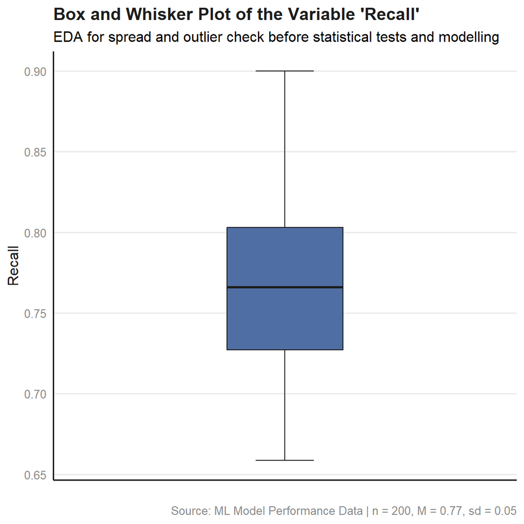

```r
# `col_index` identifies which column(s) (by position) are being plotted;
# seq_along() generates 1, 2, ..., ncol(data_frame) automatically,
# so every column in the data frame is covered without manually listing
# positions
col_index <- seq_along(ml_performance_data)

# the right-hand `col_index` (the full vector) is evaluated once when the
# loop starts; col_index is then reassigned to one position per iteration.
for (col_index in col_index) {

  # skip silently, with no message/warning, if the position does not exist
  # in the data (out of range) or if the column at that position is not
  # numeric; `next` moves straight to the following value of col_index
  if (col_index > ncol(ml_performance_data) ||
      !is.numeric(ml_performance_data[[col_index]])) {
    next
  }

  col_name <- names(ml_performance_data)[col_index]

  p <- ggplot2::ggplot(ml_performance_data, aes(x = "", y = .data[[col_name]])) +
    stat_boxplot(geom = "errorbar", width = 0.15, color = "#1D1D1D") +
    geom_boxplot(fill = "#4F6EA4", color = "#1D1D1D", width = 0.3) +

    # reduces the default 5% padding on the x and y axes
    # scale_x_continuous(expand = expansion(mult = c(0.00, 0.00))) +
    # scale_y_continuous(expand = expansion(mult = c(0.00, 0.00))) +
    labs(
      title = paste0("Box and Whisker Plot of the Variable '", col_name, "'"),
      subtitle = paste0("EDA for spread and outlier check before ",
                        "statistical tests and modelling"),
      x = NULL,  # no x-axis label needed
      y = col_name,
      caption = paste0("Source: ML Model Performance Data | n = ",
                       nrow(ml_performance_data), ", ",
                       "M = ",
                       sprintf("%.2f",
                               mean(ml_performance_data[[col_name]], na.rm = TRUE)),
                       ", ",
                       "sd = ",
                       sprintf("%.2f",
                               sd(ml_performance_data[[col_name]], na.rm = TRUE)))
    ) +
    theme_minimal(base_size = 12) +

    theme(
      plot.title          = element_text(face = "bold", color = "#1D1D1D"),
      axis.title          = element_text(color = "#1D1D1D"),
      axis.text           = element_text(color = "#898989"),
      # axis.text.x         = element_text(angle = 30, hjust = 1),
      plot.caption         = element_text(color = "#898989"),
      # removes vertical gridlines
      panel.grid.major.x  = element_blank(),
      panel.grid.minor.x  = element_blank(),
      # horizontal gridlines are kept (at major breaks only) since they
      # help the reader judge bar heights against the y-axis scale
      panel.grid.minor.y  = element_blank(),
      # draws only the x-axis and y-axis lines (the "L" frame)
      axis.line.x         = element_line(color = "#1D1D1D"),
      axis.line.y         = element_line(color = "#1D1D1D")
      # panel.border = element_rect(color = "#1D1D1D", fill = NA,
      #                            linewidth = 0.5)
    )
  # ggplot objects do not auto-print inside a for-loop, therefore,
  # each one must be printed explicitly otherwise it will never appear
  print(p)
}
```

### 3.4.3 **Missing Data Plot**

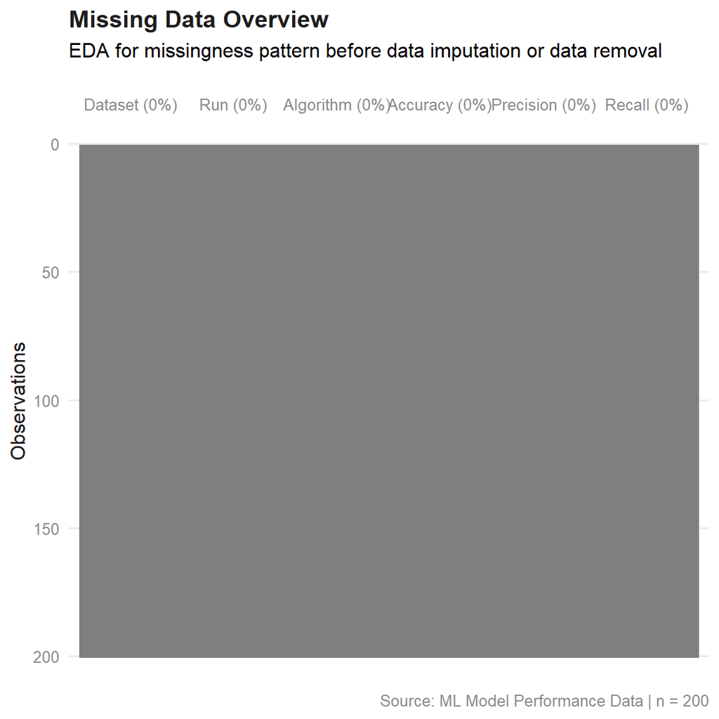

```r
# `vis_miss()` plots a matrix of observations (rows) by variables (columns),
# shading each cell by whether the value is missing or present; this is
# the ggplot2-native counterpart to Amelia's missmap()
naniar::vis_miss(ml_performance_data) +
  labs(
    title = "Missing Data Overview",
    subtitle = "EDA for missingness pattern before data imputation or data removal",
    caption = paste0("Source: ML Model Performance Data | n = ",
                     nrow(ml_performance_data))
  ) +
  # overrides vis_miss()'s default black/grey fill; vis_miss() has no
  # built-in color argument, but since it returns a standard ggplot
  # object, the fill scale can be replaced afterward like any other
  scale_fill_manual(values = c("Present" = "#4F6EA4", "Missing" = "#E03C31")) +

  theme_minimal(base_size = 12) +

  theme(
    plot.title          = element_text(face = "bold", color = "#1D1D1D"),
    axis.title          = element_text(color = "#1D1D1D"),
    axis.text           = element_text(color = "#898989"),
    # axis.text.x         = element_text(angle = 30, hjust = 1),
    plot.caption         = element_text(color = "#898989"),
    # removes vertical gridlines
    panel.grid.major.x  = element_blank(),
    panel.grid.minor.x  = element_blank(),
    # horizontal gridlines are kept (at major breaks only) since they
    # help the reader judge bar heights against the y-axis scale
    panel.grid.minor.y  = element_blank(),
    # draws only the x-axis and y-axis lines (the "L" frame)
    # axis.line.x         = element_line(color = "#1D1D1D"),
    # axis.line.y         = element_line(color = "#1D1D1D")
    # panel.border = element_rect(color = "#1D1D1D", fill = NA,
                               # linewidth = 0.5)
  )
```

### 3.4.4 **Scatter Plot**

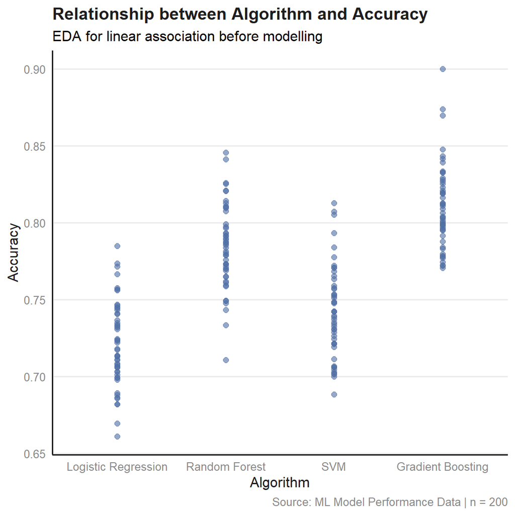

```r
ggplot2::ggplot(ml_performance_data,
                aes(x = Algorithm, y = Accuracy)) +
  # points use the blue-grey theme discussed in class,
  # with partial transparency (alpha) so overlapping points are visible
  # rather than solid black dots which obscure density.
  geom_point(color = "#4F6EA4", alpha = 0.6, size = 2) +
  # regression line in the near-black used for borders/axis text elsewhere,
  # with a light blue-grey confidence ribbon instead of the default grey
  geom_smooth(method = lm, color = "#1D1D1D", fill = "#A9C0DA") +
  labs(
    title = "Relationship between Algorithm and Accuracy",
    subtitle = "EDA for linear association before modelling",
    x = "Algorithm",
    y = "Accuracy",
    caption = paste0("Source: ML Model Performance Data | n = ",
                     nrow(ml_performance_data))
  ) +

  theme_minimal(base_size = 12) +

  theme(
    plot.title          = element_text(face = "bold", color = "#1D1D1D"),
    axis.title          = element_text(color = "#1D1D1D"),
    axis.text           = element_text(color = "#898989"),
    # axis.text.x         = element_text(angle = 30, hjust = 1),
    plot.caption        = element_text(color = "#898989"),
    # removes vertical gridlines
    panel.grid.major.x  = element_blank(),
    panel.grid.minor.x  = element_blank(),
    # horizontal gridlines are kept (at major breaks only) since they
    # help the reader judge point position against the y-axis scale
    panel.grid.minor.y  = element_blank(),
    # draws only the x-axis and y-axis lines (the "L" frame)
    axis.line.x         = element_line(color = "#1D1D1D"),
    axis.line.y         = element_line(color = "#1D1D1D")
    # panel.border = element_rect(color = "#1D1D1D", fill = NA,
    # linewidth = 0.5)
  )
```

`geom_smooth(method = "lm")` fits a linear regression, which requires a continuous x-variable; `Algorithm` is categorical, therefore, this is not useful. Below is an alternative for a case where you have categorical data.

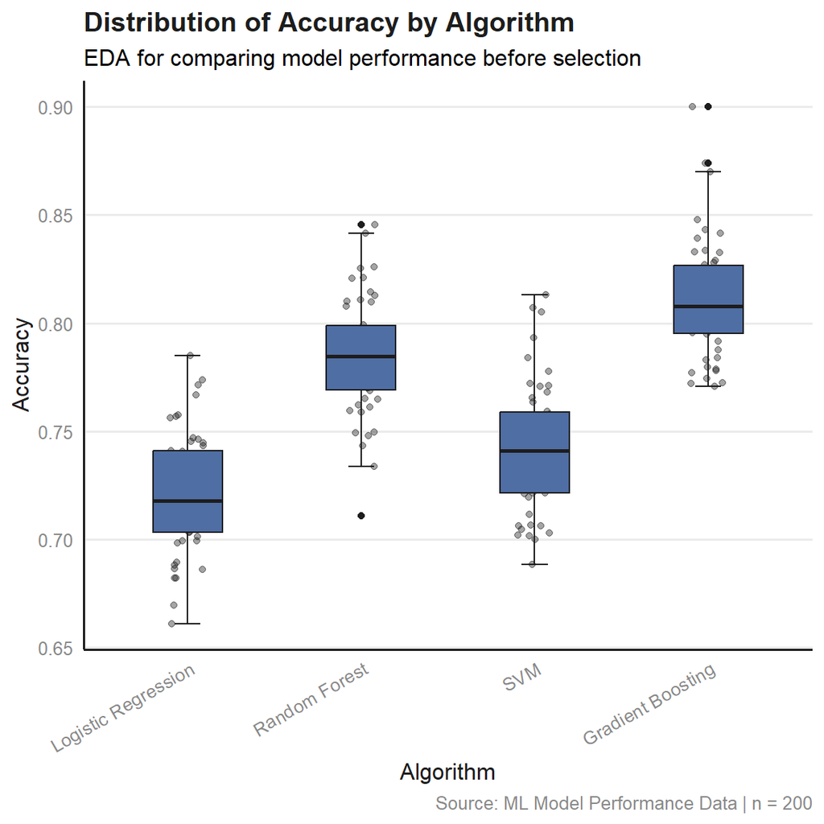

```r
ggplot2::ggplot(ml_performance_data,
                aes(x = Algorithm, y = Accuracy)) +
  stat_boxplot(geom = "errorbar", width = 0.15, color = "#1D1D1D") +
  # layering the raw data points underneath the boxes with geom_jitter()
  # shows you both the summary statistics and the actual spread/sample size
  # per category, which a box alone hides, for instance you cannot tell
  # from a box alone whether one category was tested on 5 runs and another
  # on 50.
  geom_jitter(width = 0.1, alpha = 0.4, color = "#1D1D1D", size = 1.5) +
  # one box per category
  geom_boxplot(fill = "#4F6EA4", color = "#1D1D1D", width = 0.4) +
  labs(
    title = "Distribution of Accuracy by Algorithm",
    subtitle = "EDA for comparing model performance before selection",
    x = "Algorithm",
    y = "Accuracy",
    caption = paste0("Source: ML Model Performance Data | n = ",
                     nrow(ml_performance_data))
  ) +
  theme_minimal(base_size = 12) +
  theme(
    plot.title          = element_text(face = "bold", color = "#1D1D1D"),
    axis.title          = element_text(color = "#1D1D1D"),
    axis.text           = element_text(color = "#898989"),
    # uncomment if algorithm names are long enough to overlap when
    # printed horizontally (e.g. "Random Forest", "Gradient Boosting")
    axis.text.x        = element_text(angle = 30, hjust = 1),
    plot.caption         = element_text(color = "#898989"),
    # vertical gridlines removed: even with categorical groups on x,
    # there is no continuous scale for the lines to reference, so they
    # add no information
    panel.grid.major.x  = element_blank(),
    panel.grid.minor.x  = element_blank(),
    panel.grid.minor.y  = element_blank(),
    # draws only the x-axis and y-axis lines (the "L" frame)
    axis.line.x         = element_line(color = "#1D1D1D"),
    axis.line.y         = element_line(color = "#1D1D1D")
    # panel.border = element_rect(color = "#1D1D1D", fill = NA,
    # linewidth = 0.5)
  )
```

# 4 Statistical Test: ANOVA

## 4.1 One-Way ANOVA

**Purpose:** Compares the means of three or more groups defined by a single categorical independent variable, to test whether at least one group differs from the others.  
**Variables:** One categorical independent variable (three or more levels); one continuous dependent variable.  
**Output:** A single F-statistic and p-value; if significant, followed by a post-hoc test (e.g., Tukey’s HSD) to identify which specific groups differ.  
**Example:** Comparing Accuracy across four algorithms used to train ML models (accuracy depends on the chosen algorithm).

```r
one_way_anova_result <- aov(Accuracy ~ Algorithm, data = ml_performance_data)
summary(one_way_anova_result)
```

```
#>              Df Sum Sq Mean Sq F value Pr(>F)
#> Algorithm     3 0.2469 0.08230   104.7 <2e-16 ***
#> Residuals   196 0.1540 0.00079
#> ---
#> Signif. codes:  0 '***' 0.001 '**' 0.01 '*' 0.05 '.' 0.1 ' ' 1
```

Effect size addresses a gap that the F-test and p-value do not: those tell you whether the groups differ by more than chance, but not how much of the outcome’s variability is actually attributable to the grouping factor. Eta squared (η²) answers that second question. It is defined as the proportion of total variance in the dependent variable explained by the factor.

```r
# effect size (eta squared): proportion of total variance explained by
# Algorithm; computed directly from the Sum Sq values already in the
# summary table, no extra package required
ss <- summary(one_way_anova_result)[[1]][["Sum Sq"]]
eta_squared_oneway <- ss[1] / sum(ss)
eta_squared_oneway
```

```
#> [1] 0.6158641
```

```r
TukeyHSD(one_way_anova_result)
```

```
#>   Tukey multiple comparisons of means
#>     95% family-wise confidence level
#>
#> Fit: aov(formula = Accuracy ~ Algorithm, data = ml_performance_data)
#>
#> $Algorithm
#>                                              diff          lwr         upr
#> Random Forest-Logistic Regression      0.06336014  0.048833192  0.07788709
#> SVM-Logistic Regression                0.02135088  0.006823931  0.03587783
#> Gradient Boosting-Logistic Regression  0.08998747  0.075460525  0.10451442
#> SVM-Random Forest                     -0.04200926 -0.056536211 -0.02748231
#> Gradient Boosting-Random Forest        0.02662733  0.012100383  0.04115428
#> Gradient Boosting-SVM                  0.06863659  0.054109644  0.08316354
#>                                           p adj
#> Random Forest-Logistic Regression     0.0000000
#> SVM-Logistic Regression               0.0010661
#> Gradient Boosting-Logistic Regression 0.0000000
#> SVM-Random Forest                     0.0000000
#> Gradient Boosting-Random Forest       0.0000232
#> Gradient Boosting-SVM                 0.0000000
```

## 4.2 Two-Way ANOVA

**Purpose:** Examines the effects of two categorical independent variables on a continuous outcome simultaneously, including whether the two variables interact, meaning the effect of one depends on the level of the other.  
**Variables:** Two categorical independent variables; one continuous dependent variable.  
**Output:** An F-statistic and p-value for each main effect, plus a separate F-statistic and p-value for the interaction effect; a significant interaction is interpreted before the main effects.  
**Example:** Comparing `Accuracy` across `Algorithm` and `Dataset`, and testing whether an algorithm’s relative performance changes depending on which dataset it was run on.

```r
ml_performance_data$Algorithm <- as.factor(ml_performance_data$Algorithm)
ml_performance_data$Dataset   <- as.factor(ml_performance_data$Dataset)

two_way_anova_result <- aov(Accuracy ~ Algorithm * Dataset, data = ml_performance_data)
shapiro.test(residuals(two_way_anova_result))
```

```
#>
#>  Shapiro-Wilk normality test
#>
#> data:  residuals(two_way_anova_result)
#> W = 0.99391, p-value = 0.587
```

```r
leveneTest(Accuracy ~ Algorithm * Dataset, data = ml_performance_data)
```

|  | Df | F value | Pr(>F) |
| --- | --- | --- | --- |
| group | 39 | 0.9075325 | 0.6285099 |
|  | 160 | NA | NA |

```r
# `Algorithm * Dataset` tests both main effects and their interaction;
# a significant interaction would mean an algorithm's relative
# performance depends on which dataset it was run on, not just on
# the algorithm itself
summary(two_way_anova_result)
```

```
#>                    Df  Sum Sq Mean Sq F value Pr(>F)
#> Algorithm           3 0.24691 0.08230  99.175 <2e-16 ***
#> Dataset             9 0.00601 0.00067   0.805  0.612
#> Algorithm:Dataset  27 0.01521 0.00056   0.679  0.881
#> Residuals         160 0.13278 0.00083
#> ---
#> Signif. codes:  0 '***' 0.001 '**' 0.01 '*' 0.05 '.' 0.1 ' ' 1
```

Effect size addresses a gap that the F-test and p-value do not: those tell you whether the groups differ by more than chance, but not how much of the outcome’s variability is actually attributable to the grouping factor. Eta squared (η²) answers that second question. It is defined as the proportion of total variance in the dependent variable explained by the factor.

```r
ss <- summary(two_way_anova_result)[[1]][["Sum Sq"]]
row_names <- rownames(summary(two_way_anova_result)[[1]])

eta_squared_twoway <- ss / sum(ss)
names(eta_squared_twoway) <- trimws(row_names)
eta_squared_twoway
```

```
#>         Algorithm           Dataset Algorithm:Dataset         Residuals
#>        0.61586412        0.01500130        0.03794224        0.33119234
```